# Species range maps in R

Stuff TODO: ————————————————————-

Easy: write a script to download occurrence data from GBIF for a species and display them on a map

Medium: Draw a convex hull polygon around the points in the earlier test.

Hard: Clip the polygon you generated in medium test to world map (Keep only part of the polygon which is on land).

### 1. Get gbif species point data:

Tasks: write function that retrieves point data for given species. Potential arguments - return_clean (clean data with that Ropensci pkg), bounding_box - return for given bounding box, country - return for given country

#### 2. Draw polygons around points

# Bonus: fit bioclim model to filter out suitable habitat within the EOO

```r
if(!require(pacman))
{
  install.packages("pacman")
}
pacman::p_load(spocc, sf, mapview, lubridate, dplyr, raster,
               sf, scrubr, stringr, sp, rgeos, dismo, broom)
```

## Working with speciesrangeR

We will load here speciesrangeR package. Temporarily it is a set of scripts that can be sourced, but will be replaced with package that can be installed via devtools. Use get_species_data() to query [GBIF](https://www.gbif.org/). Function is a wrapper around occ() function from [spocc](https://ropensci.github.io/spocc/) package.

```r
# source("https://github.com/MirzaCengic/speciesrangeR/blob/master/R/get_species_data.R")
source("Y:/Mirza_Cengic/Projects/Other/GSoC/R/get_species_data.R")
source("Y:/Mirza_Cengic/Projects/Other/GSoC/R/get_eoo.R")
source("Y:/Mirza_Cengic/Projects/Other/GSoC/R/get_esh.R")
```

## Get occurence data from [GBIF](https://www.gbif.org/)

Here we will retrieve species occurence data for species Salamandra atra. Function get_species_data() can take country argument, so we will query for data for Italy. Default limit of spocc:occ() function is 500 points, however you can pass a numeric value to “limit” argument. Country data is filtered afterwards, therefore the number of points does not have to correspond to limit. See help of the function for more details.

We will inspect the data with some interactive mapping.

```r
sal_atra_ita <- get_species_data("Salamandra atra", return_clean = TRUE,
                                 return = "sp", country = "ITA")
# Plot maps
# mapview(sal_atra_ita)
plot(sal_atra_ita)
```

[output not shown]

One point is in Torino and is clearly wrong datapoint. Most likely the point is assigned to an instution where the specimen is storaged.

```r
sal_atra_ita
```

```
class       : SpatialPointsDataFrame
features    : 17
extent      : 7.7, 12.95494, 45.0666, 46.98567  (xmin, xmax, ymin, ymax)
coord. ref. : +proj=longlat +datum=WGS84 +no_defs +ellps=WGS84 +towgs84=0,0,0
variables   : 4
names       :            name, prov,       date,        key
min values  : Salamandra atra, gbif, 2001-06-13,  876326354
max values  : Salamandra atra, gbif, 2017-09-01, 1831145518
```

Calculates excent of occurence using minimum convex hull from rgeos package. Can return simple feature or spatial points dataframe.

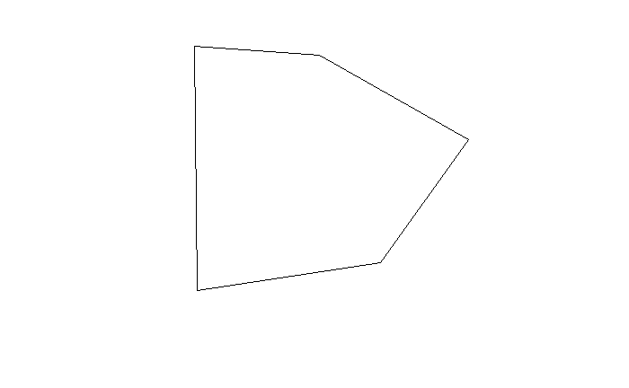